# An analysis on bitcoin volatility

Joon Park

May 17, 2018

## Introduction

This past year a new craze swept the nation. Cryptocurrency trading has peaked in 2017 and still continues to grow in 2018. With all the millions being made many have tried speculating on when a cryptocurrency will “moon”. Today I hope to collect data and analyze various factors of a particular cryptocurrency called bitcoin which has attracted the most attention due to the enormous gains it has made in value. I hope that you enjoy the analysis.

## Libraries

Please install these libraries before we begin broom stringr lubridate tidyverse ggplot2 zoo

# Data curation/Tidying

To begin we must first obtain the data on the cryptocurrency we want to view. This can be accessed through Kaggle https://www.kaggle.com/jessevent/all-crypto-currencies. This data is saved as a csv file and so I use R’s read_csv function to obtain the data and store it in a dataframe I named crypto_data. This data is data recorded on daily cryptocurrency open and close prices on coin exchanges for many coins including Bitcoin.

```r
library(stringr)
library(tidyverse)
crypto_data <- read_csv("crypto-markets.csv")
crypto_data %>% head()
```

```
## # A tibble: 6 x 13
##   slug   symbol name   date  ranknow  open  high   low close volume market
##   <chr>  <chr>  <chr>  <chr>   <int> <dbl> <dbl> <dbl> <dbl>  <int>  <dbl>
## 1 bitco~ BTC    Bitco~ 4/28~       1   135   136 132   134        0 1.50e9
## 2 bitco~ BTC    Bitco~ 4/29~       1   134   147 134   145        0 1.49e9
## 3 bitco~ BTC    Bitco~ 4/30~       1   144   147 134   139        0 1.60e9
## 4 bitco~ BTC    Bitco~ 5/1/~       1   139   140 108   117        0 1.54e9
## 5 bitco~ BTC    Bitco~ 5/2/~       1   116   126  92.3 105        0 1.29e9
## 6 bitco~ BTC    Bitco~ 5/3/~       1   106   108  79.1  97.8      0 1.18e9
## # ... with 2 more variables: close_ratio <dbl>, spread <dbl>
```

```r
library(ggplot2)
library(lubridate)
## filtering only the data on bitcoin
bitcoin_data <- crypto_data %>%
                filter(name == "Bitcoin")
bitcoin_data %>% head()
```

```
## # A tibble: 6 x 13
##   slug   symbol name   date  ranknow  open  high   low close volume market
##   <chr>  <chr>  <chr>  <chr>   <int> <dbl> <dbl> <dbl> <dbl>  <int>  <dbl>
## 1 bitco~ BTC    Bitco~ 4/28~       1   135   136 132   134        0 1.50e9
## 2 bitco~ BTC    Bitco~ 4/29~       1   134   147 134   145        0 1.49e9
## 3 bitco~ BTC    Bitco~ 4/30~       1   144   147 134   139        0 1.60e9
## 4 bitco~ BTC    Bitco~ 5/1/~       1   139   140 108   117        0 1.54e9
## 5 bitco~ BTC    Bitco~ 5/2/~       1   116   126  92.3 105        0 1.29e9
## 6 bitco~ BTC    Bitco~ 5/3/~       1   106   108  79.1  97.8      0 1.18e9
## # ... with 2 more variables: close_ratio <dbl>, spread <dbl>
```

Now we have the data we need, but our dataframe still has unnecessary columns that clutter up our dataframe.

```r
## selecting only the columns that are necessary to our analysis
bitcoin_data <- bitcoin_data %>% select(name,open,close,high,low,date,volume,market)
bitcoin_data
```

```
## # A tibble: 1,793 x 8
##    name     open close  high   low date      volume     market
##    <chr>   <dbl> <dbl> <dbl> <dbl> <chr>      <int>      <dbl>
##  1 Bitcoin 135   134     136 132   4/28/2013      0 1500520000
##  2 Bitcoin 134   145     147 134   4/29/2013      0 1491160000
##  3 Bitcoin 144   139     147 134   4/30/2013      0 1597780000
##  4 Bitcoin 139   117     140 108   5/1/2013       0 1542820000
##  5 Bitcoin 116   105     126  92.3 5/2/2013       0 1292190000
##  6 Bitcoin 106    97.8   108  79.1 5/3/2013       0 1180070000
##  7 Bitcoin  98.1 112     115  92.5 5/4/2013       0 1089890000
##  8 Bitcoin 113   116     119 107   5/5/2013       0 1254760000
##  9 Bitcoin 116   112     125 107   5/6/2013       0 1289470000
## 10 Bitcoin 112   112     113  97.7 5/7/2013       0 1248470000
## # ... with 1,783 more rows
```

```r
##converting the date to a uniform format so R can recognize it easily
bitcoin_data$date <- as.Date(bitcoin_data$date,"%m/%d/%Y")

##creating a new column in the dataframe called year
bitcoin_data <- bitcoin_data %>% mutate(year = year(date)) %>%
                 select(name,open,close,high,low,date,year,market,volume)
bitcoin_data
```

```
## # A tibble: 1,793 x 9
##    name     open close  high   low date        year     market volume
##    <chr>   <dbl> <dbl> <dbl> <dbl> <date>     <dbl>      <dbl>  <int>
##  1 Bitcoin 135   134     136 132   2013-04-28  2013 1500520000      0
##  2 Bitcoin 134   145     147 134   2013-04-29  2013 1491160000      0
##  3 Bitcoin 144   139     147 134   2013-04-30  2013 1597780000      0
##  4 Bitcoin 139   117     140 108   2013-05-01  2013 1542820000      0
##  5 Bitcoin 116   105     126  92.3 2013-05-02  2013 1292190000      0
##  6 Bitcoin 106    97.8   108  79.1 2013-05-03  2013 1180070000      0
##  7 Bitcoin  98.1 112     115  92.5 2013-05-04  2013 1089890000      0
##  8 Bitcoin 113   116     119 107   2013-05-05  2013 1254760000      0
##  9 Bitcoin 116   112     125 107   2013-05-06  2013 1289470000      0
## 10 Bitcoin 112   112     113  97.7 2013-05-07  2013 1248470000      0
## # ... with 1,783 more rows
```

# Exploratory Data Analysis

Now that most of the data is cleaned we can get an initial picture of our data and what it looks like

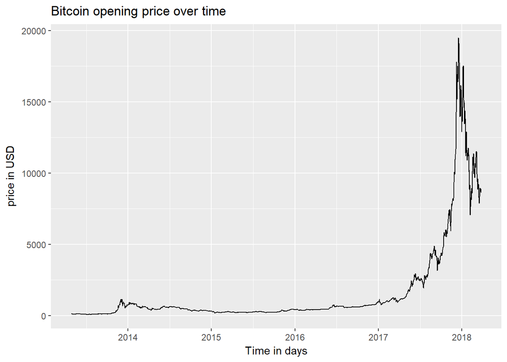

```r
## creating a graph of opening prices over time
bitcoin_data %>%
                  ggplot()+
                  geom_line(aes(x=date,y=open),color='black')+
                  xlab("Time in days")+
                  ylab("price in USD") +
                  ggtitle("Bitcoin opening price over time")
```

judging from the graph it seems pretty obvious that Bitcoin made it’s breakthrough around the mid 2017 year. Our goal for this data is to determine what factors were a big part of this jump and how important these factors are. To start let’s go over a metric used in stock prediction called rolling averages. ROlling or moving averages are averages calculated over a defined number of time periods for example in the code below we determine two different rolling averages over the course of Bitcoin’s trading history. One is the 30 day rolling average and the other is a 60 day rolling average. Both take the average opening price over their specified time period more information can be found in this link.https://www.investopedia.com/terms/m/movingaverage.asp

```r
library(zoo)
updated_btc_data <- bitcoin_data %>%

  ##create a new column for both 30 day and 60 day rolling averages by using zoo's built in function
                    mutate(thirty_r_avg = rollmean(bitcoin_data$open,30,fill = NA, align = "right")) %>%
                    mutate(sixty_r_avg = rollmean(bitcoin_data$open,60,fill = NA, align = "right")) %>%
                    select(name,open,close,high,market,low,date,thirty_r_avg,sixty_r_avg,volume)
```

ROlling averages are important for finding general trends of a stock and how well it performs over time as it takes the average over a certain period of time.

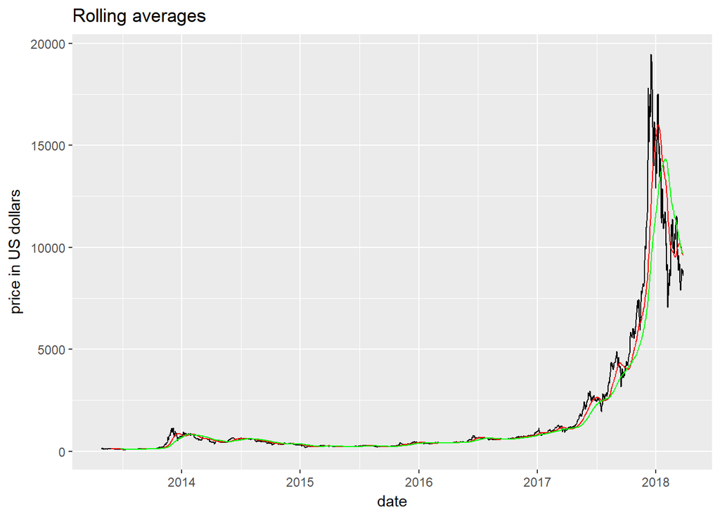

```r
    updated_btc_data %>% ggplot(aes (x = date),color= factor() )+
                    geom_line(aes(y=open),color = 'black') +
                    geom_line(aes(y=thirty_r_avg),color='red') +
                    geom_line(aes(y=sixty_r_avg),color = 'green') +
                    xlab("date") +
                    ylab("price in US dollars") +
                    ggtitle("Rolling averages")
```

The plot above shows the opening prices of Bitcoin over time followed by the 30 day rolling average in red and 60 day rolling average in green however it might be a bit hard to see over the entire time series so let’s zoom in a little. This plot shows over the data over the time period of 2017.

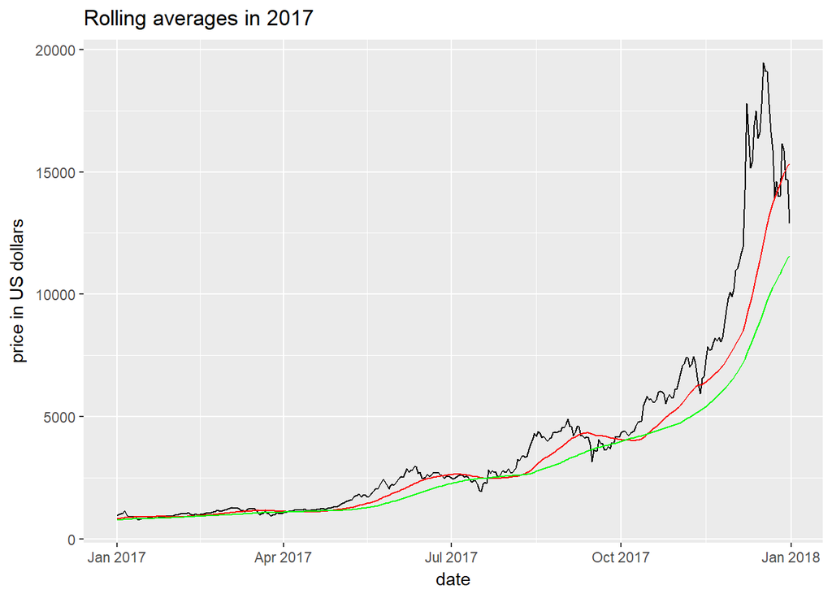

```r
#filtering by year to make the plot more zoomed in
sample_size <- updated_btc_data %>%
                filter(year(date) == 2017)

sample_size %>% ggplot()+
                    geom_line(aes(x=date,y=open),color = 'black') +
                    geom_line(aes(x=date,y=thirty_r_avg),color='red') +
                    geom_line(aes(x=date,y=sixty_r_avg),color = 'green') +
                    xlab("date") +
                    ylab("price in US dollars") +
                    ggtitle("Rolling averages in 2017")
```

The rolling averages correlates strongly with the actual open price and can be useful for interpreting trends. For example in the plot above whenever the red lines overtake the green lines it means the short term growth is larger than the long term growth. Vice versa if the red lines are below the green lines it means the long term growth is performing better than the short term.

Rolling Averages tell general trends however they aren’t entirely useful when considering something as volatile as cryptocurrency. Unlike stocks, cryptocurrency is a lot more volatile in terms of price, which begs the question how do we measure this volatility ?

To measure volatility we can take the difference between the high and low and have that act as the range of the price for that day.

```r
#creating a new column called flucutation which is the absolute value of the range
fluctuations_df <- updated_btc_data %>%
                mutate(fluctuation = abs(high - low)) %>%
                select(name,open,close,high,volume,low,date,fluctuation)
```

Now that we have the fluctuations lets see what it looks like.

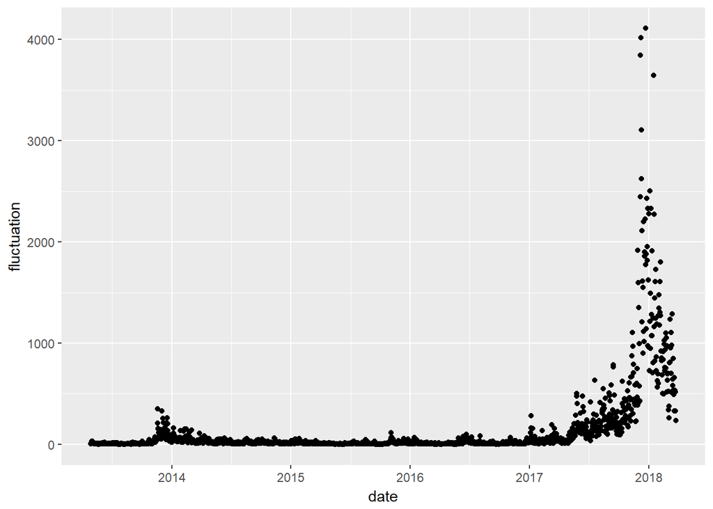

```r
fluctuations_df %>% ggplot(aes(x=date,y=fluctuation)) +
                    geom_point()
```

This plot looks very similar to the opening price plot that was shown at the very beginning of this tutorial which indicates that there might be a very strong correlation there.Now we can ask the question what is causing all this volatility? To be honest it could be anything, market capitalization, Trump becoming president, pump and dump due to lack of regulation, etc etc, but for the purpose of this data analysis let’s focus more on the attributes that we can measure from the data, for example market capitalization.

Market capitalization is a measure of how big a certain company or stock is (in this case it’s crypto). More information and definitions can be found here https://www.investopedia.com/articles/basics/03/031703.asp. This is very important as many beginning crypto traders simply rank coins by price without looking at their value in relation to market capitalization.

Like in the case of volatility, market cap seems to follow an incredibly similar trend to opening price.

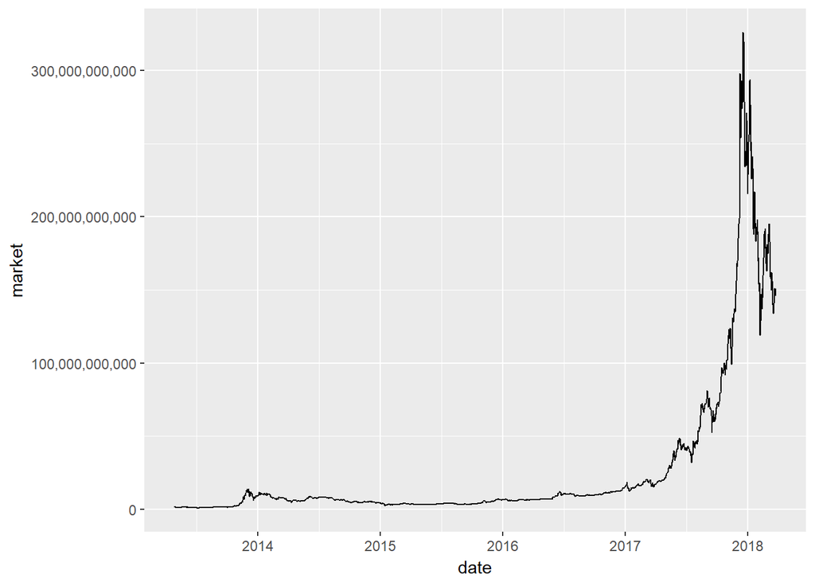

```r
bitcoin_data %>%
              ggplot(aes(x=date,y=market))+

              ## creates a line graph
              geom_line() +

              ##formatting to display correct labels
              scale_y_continuous(labels = scales::comma)
```

There seems to be striking similarities between the market capitalization, volatility, and opening price of this data. I believe that there is a correlation between all of these variables and volume which accounts for the stated similarities. Plotting it also helps to show the correlation.

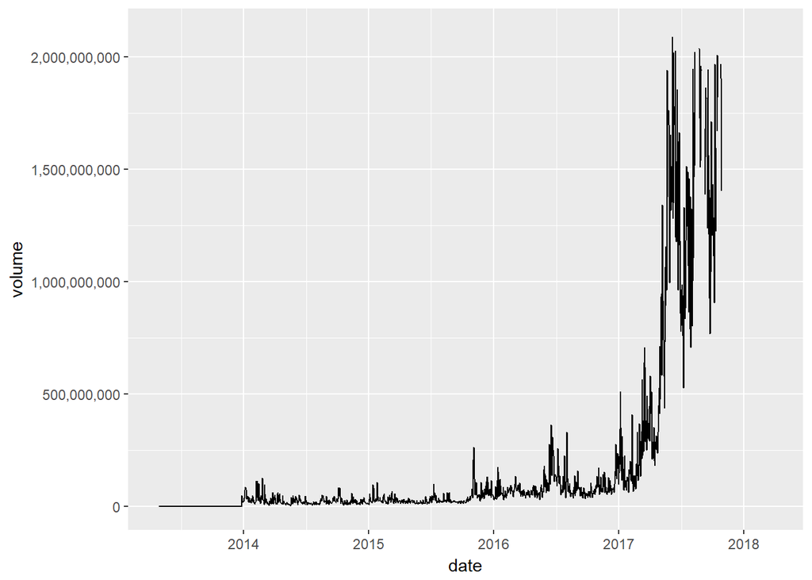

```r
##plotting volume over time
bitcoin_data %>%
              ggplot(aes(x=date,y=volume))+
              geom_line() +
              scale_y_continuous(labels = scales::comma)
```

# Hypothesis testing

To test our initial hypothesis that there is a correlation between 2 columns we are going to use a linear regression model. Linear regression is a powerful technique that allows us to test the strength of a relationship between two attributes. We will focus mainly on volume and volatility Lets start with volume and volatility. Our null hypothesis is that there is no correlation between volume and volatility while conversely our alternative hypothesis is that there is a definable correlation between volume and volatility

```r
##fitting the linear regression model with the interaction of volatility and volume then using tidy to clean it up.
r1 <- lm(fluctuation~volume,data =fluctuations_df)
broom::tidy(r1)
```

```
##          term     estimate    std.error statistic      p.value
## 1 (Intercept) 1.417435e+01 9.684666e-01  14.63587 1.220432e-45
## 2      volume 1.251812e-07 2.232475e-09  56.07281 0.000000e+00
```

```r
library(broom)

#summarizing the data and displaying it
summarized_r1 <- r1 %>% summary()

summarized_r1
```

```
##
## Call:
## lm(formula = fluctuation ~ volume, data = fluctuations_df)
##
## Residuals:
##     Min      1Q  Median      3Q     Max
## -151.87  -13.02   -8.18    2.66  335.55
##
## Coefficients:
##              Estimate Std. Error t value Pr(>|t|)
## (Intercept) 1.417e+01  9.685e-01   14.64   <2e-16 ***
## volume      1.252e-07  2.232e-09   56.07   <2e-16 ***
## ---
## Signif. codes:  0 '***' 0.001 '**' 0.01 '*' 0.05 '.' 0.1 ' ' 1
##
## Residual standard error: 35.61 on 1613 degrees of freedom
##   (178 observations deleted due to missingness)
## Multiple R-squared:  0.6609, Adjusted R-squared:  0.6607
## F-statistic:  3144 on 1 and 1613 DF,  p-value: < 2.2e-16
```

Here we try to see just how well our linear model was fit. What we are focusing on for now is the residual standard error which lets us know how well our model was fit. In our case our r squared was .6607 or around 66% of the variance could be explained through our data.

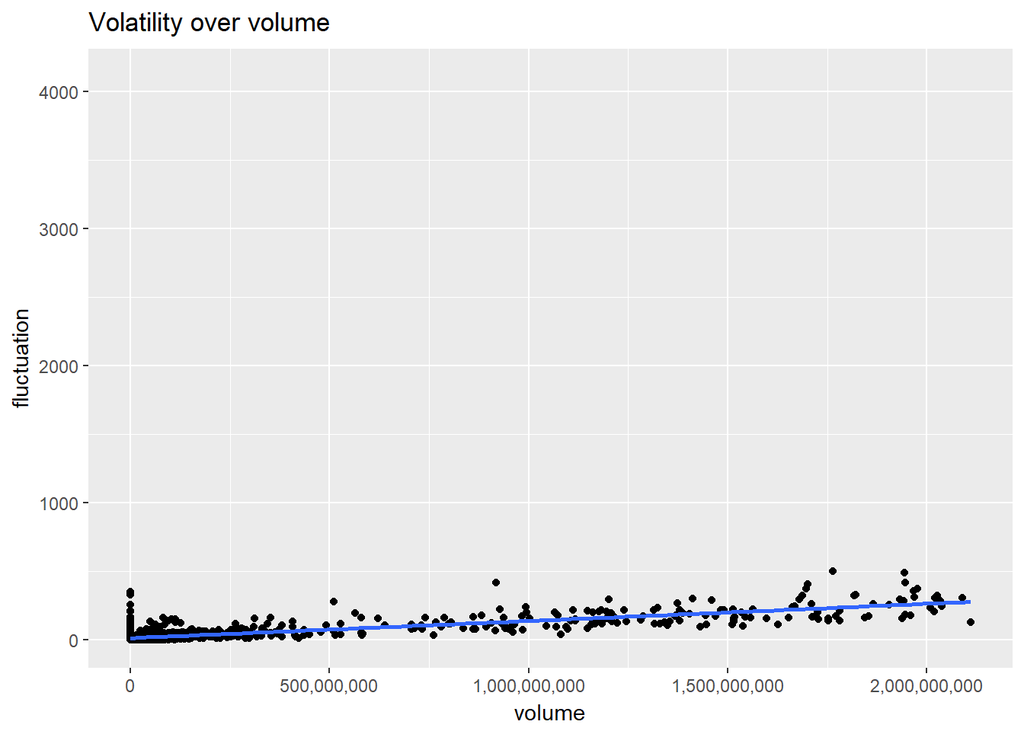

```r
fluctuations_df %>% ggplot(aes(x=volume,y=fluctuation)) +
                    geom_point() +
                    geom_smooth(method =lm) +
                    scale_colour_gradient(low = "black", high = "blue")+
                    scale_x_continuous(labels = scales::comma) +
                    ggtitle("Volatility over volume")
```

By looking at the model we can definitely infer that there is a correlation between volume and fluctuation however it was smaller than expected. This could be due to skewed data as a larger portion of recorded results seem to be on the lower end of the graph

Looking back on our r1 we can see that our p-value is much less than the standard significance level at .05 and can confidently say that there is a correlation between volume and volatility.

```r
summarized_r1
```

```
##
## Call:
## lm(formula = fluctuation ~ volume, data = fluctuations_df)
##
## Residuals:
##     Min      1Q  Median      3Q     Max
## -151.87  -13.02   -8.18    2.66  335.55
##
## Coefficients:
##              Estimate Std. Error t value Pr(>|t|)
## (Intercept) 1.417e+01  9.685e-01   14.64   <2e-16 ***
## volume      1.252e-07  2.232e-09   56.07   <2e-16 ***
## ---
## Signif. codes:  0 '***' 0.001 '**' 0.01 '*' 0.05 '.' 0.1 ' ' 1
##
## Residual standard error: 35.61 on 1613 degrees of freedom
##   (178 observations deleted due to missingness)
## Multiple R-squared:  0.6609, Adjusted R-squared:  0.6607
## F-statistic:  3144 on 1 and 1613 DF,  p-value: < 2.2e-16
```

# closing remarks

A couple of references : Kaggle Datasets https://www.kaggle.com/datasets Investopedia https://www.investopedia.com/ Crypto volatility: https://www.cryptocompare.com/coins/guides/5-things-you-need-to-know-about-bitcoin-volatility/ basic r functions/tidying : https://rpubs.com/bradleyboehmke/data_wrangling plotting: https://tutorials.iq.harvard.edu/R/Rgraphics/Rgraphics.html